# CalFishTrack

# *Central Valley Enhanced*

# *Acoustic Tagging Project*

[figure not shown]

# *Real-time tracking Diagnostics*

*Data current as of 2021-04-29 06:00:00. Updates occur hourly. All times in Pacific Standard Time.*

## Map of Active Real-time Receiver Sites

[interactive chart not shown]

## Deployed Realtime receiver sites

| recv | location | general_location | latitude | longitude | rkm |
| --- | --- | --- | --- | --- | --- |
| 18002 | ButteBrRT_1 | ButteBrRT | 39.45685 | -121.9949 | 344.108 |
| 19030 | ButteBrRT_2 | ButteBrRT | 39.45684 | -121.9948 | 344.108 |
| 157004 | TowerBr2 | TowerBridge | 38.58044 | -121.5086 | 172.000 |
| 157002 | TowerBr1 | TowerBridge | 38.58046 | -121.5087 | 172.000 |
| 18003 | TowerBr3 | TowerBridge | 38.58029 | -121.5079 | 172.000 |
| 157003 | I80-50_Br3 | I80-50_Br | 38.57115 | -121.5162 | 170.748 |
| 157005 | I80-50_Br2 | I80-50_Br | 38.57117 | -121.5163 | 170.748 |
| 17048 | I80-50_Br1 | I80-50_Br | 38.57058 | -121.5157 | 170.748 |
| 18007 | RT_OldRiver | Old River | 37.93958 | -121.5611 | 153.001 |
| 18004 | RT_MiddleRiver | MiddleRiver | 37.93970 | -121.5338 | 150.000 |
| 19057 | Holland_Cut_Quimby_2 | Holland_Cut_Quimby | 38.01647 | -121.5807 | 145.000 |
| 19066 | Holland_Cut_Quimby_3 | Holland_Cut_Quimby | 38.02171 | -121.5826 | 145.000 |
| 19051 | Holland_Cut_Quimby_4 | Holland_Cut_Quimby | 38.02179 | -121.5814 | 145.000 |
| 187020 | CVP_Tank3 | CVP_Tank | 37.81586 | -121.5593 | 144.531 |
| 187018 | CVP_Tank2 | CVP_Tank | 37.81589 | -121.5592 | 144.531 |
| 187023 | SWP_intake | SWP_intake | 37.83051 | -121.5940 | 142.721 |
| 187035 | SWP_radial_gates_DS_2 | SWP_radial_gates_DS | 37.82972 | -121.5570 | 142.721 |
| 187032 | SWP_radial_gates_US_1 | SWP_radial_gates_US | 37.82960 | -121.5570 | 142.721 |
| 187033 | SWP_radial_gates_US_2 | SWP_radial_gates_US | 37.83008 | -121.5570 | 142.721 |
| 19065 | Old_River_Quimby_1 | Old_River_Quimby | 38.02506 | -121.5644 | 141.000 |
| 19049 | Old_River_Quimby_2 | Old_River_Quimby | 38.02511 | -121.5631 | 141.000 |
| 19063 | Old_River_Quimby_3 | Old_River_Quimby | 38.02824 | -121.5644 | 141.000 |
| 19059 | Old_River_Quimby_4 | Old_River_Quimby | 38.02802 | -121.5631 | 141.000 |
| 17129 | GeorgSlRT_1.1 | Georgiana_Slough1 | 38.23417 | -121.5196 | 119.208 |
| 17136 | BlGeorg_RT1.1 | Sac_BlwGeorgiana | 38.23925 | -121.5271 | 119.058 |
| 18013 | BlGeorg_RT1.2 | Sac_BlwGeorgiana | 38.23819 | -121.5269 | 119.058 |
| 17124 | BlGeorg_RT2.1 | Sac_BlwGeorgiana2 | 38.23922 | -121.5354 | 118.398 |
| 17144 | BlGeorg_RT2.2 | Sac_BlwGeorgiana2 | 38.23839 | -121.5345 | 118.398 |
| 17125 | BeniciaRT_14 | Benicia_east | 38.04165 | -122.1211 | 52.240 |
| 17126 | BeniciaRT_11 | Benicia_east | 38.04529 | -122.1242 | 52.240 |
| 17127 | BeniciaRT_13 | Benicia_east | 38.04276 | -122.1219 | 52.240 |
| 17137 | BeniciaRT_10 | Benicia_east | 38.04682 | -122.1248 | 52.240 |
| 17138 | BeniciaRT_16 | Benicia_east | 38.03864 | -122.1187 | 52.240 |
| 17141 | BeniciaRT_15 | Benicia_east | 38.04016 | -122.1200 | 52.240 |
| 18001 | BeniciaRT_09 | Benicia_east | 38.04748 | -122.1254 | 52.240 |
| 18006 | BeniciaRT_12 | Benicia_east | 38.04400 | -122.1228 | 52.240 |
| 17130 | BeniciaRT_01 | Benicia_west | 38.04490 | -122.1270 | 52.040 |
| 20046 | BeniciaRT_05 | Benicia_west | 38.03990 | -122.1230 | 52.040 |
| 17143 | BeniciaRT_07 | Benicia_west | 38.03760 | -122.1210 | 52.040 |
| 17146 | BeniciaRT_08 | Benicia_west | 38.03645 | -122.1201 | 52.040 |
| 17147 | BeniciaRT_04 | Benicia_west | 38.04123 | -122.1238 | 52.040 |
| 17148 | BeniciaRT_06 | Benicia_west | 38.03896 | -122.1219 | 52.040 |
| 18008 | BeniciaRT_02 | Benicia_west | 38.04380 | -122.1260 | 52.040 |
| 17145 | BeniciaRT_03 | Benicia_west | 38.04240 | -122.1250 | 52.040 |
| 17128 | Bench_test_1 | Bench_test | NA | NA | NA |

## Most recent downloads

| recv | start | end | location | sun_volts | bat_volts |
| --- | --- | --- | --- | --- | --- |
| 17048 | 2021-04-29 04:00:26 | 2021-04-29 05:00:26 | I80-50_Br1 | NA | NA |
| 17124 | 2021-04-29 03:07:58 | 2021-04-29 04:07:58 | BlGeorg_RT2.1 | NA | NA |
| 17125 | 2021-04-29 04:00:26 | 2021-04-29 05:00:26 | BeniciaRT_14 | NA | NA |
| 17126 | 2021-04-29 04:00:26 | 2021-04-29 05:00:26 | BeniciaRT_11 | NA | NA |
| 17127 | 2021-04-29 04:00:26 | 2021-04-29 05:00:26 | BeniciaRT_13 | NA | NA |
| 17130 | 2021-04-29 04:00:26 | 2021-04-29 05:00:26 | BeniciaRT_01 | NA | NA |
| 17136 | 2021-04-29 03:20:18 | 2021-04-29 04:20:18 | BlGeorg_RT1.1 | NA | NA |
| 17138 | 2021-04-29 04:00:26 | 2021-04-29 05:00:26 | BeniciaRT_16 | NA | NA |
| 17141 | 2021-04-29 04:00:26 | 2021-04-29 05:00:26 | BeniciaRT_15 | NA | NA |
| 17143 | 2021-04-29 04:00:26 | 2021-04-29 05:00:26 | BeniciaRT_07 | NA | NA |
| 17144 | 2021-04-29 03:31:22 | 2021-04-29 04:31:22 | BlGeorg_RT2.2 | NA | NA |
| 17145 | 2021-04-29 04:00:26 | 2021-04-29 05:00:26 | BeniciaRT_03 | NA | NA |
| 17146 | 2021-04-29 04:00:26 | 2021-04-29 05:00:26 | BeniciaRT_08 | NA | NA |
| 17147 | 2021-04-29 04:00:26 | 2021-04-29 05:00:26 | BeniciaRT_04 | NA | NA |
| 17148 | 2021-04-29 04:00:26 | 2021-04-29 05:00:26 | BeniciaRT_06 | NA | NA |
| 18001 | 2021-04-29 04:00:26 | 2021-04-29 05:00:26 | BeniciaRT_09 | NA | NA |
| 18002 | 2021-04-29 03:11:49 | 2021-04-29 04:11:49 | ButteBrRT_1 | NA | NA |
| 18003 | 2021-04-29 02:00:26 | 2021-04-29 03:00:26 | TowerBr3 | NA | NA |
| 18004 | 2021-04-29 04:00:26 | 2021-04-29 05:00:26 | RT_MiddleRiver | NA | NA |
| 18006 | 2021-04-29 04:00:26 | 2021-04-29 05:00:26 | BeniciaRT_12 | NA | NA |
| 18007 | 2021-04-29 02:00:26 | 2021-04-29 03:00:26 | RT_OldRiver | NA | NA |
| 18007 | 2021-04-29 03:00:26 | 2021-04-29 04:00:26 | RT_OldRiver | NA | NA |
| 18007 | 2021-04-29 04:00:26 | 2021-04-29 05:00:26 | RT_OldRiver | NA | NA |
| 18008 | 2021-04-29 04:00:26 | 2021-04-29 05:00:26 | BeniciaRT_02 | NA | NA |
| 18013 | 2021-04-29 04:00:36 | 2021-04-29 05:00:36 | BlGeorg_RT1.2 | NA | NA |
| 19051 | 2021-04-29 04:00:36 | 2021-04-29 05:00:36 | Holland_Cut_Quimby_4 | NA | NA |
| 19059 | 2021-04-29 03:28:18 | 2021-04-29 04:28:18 | Old_River_Quimby_4 | NA | NA |
| 19065 | 2021-04-29 02:12:54 | 2021-04-29 03:12:54 | Old_River_Quimby_1 | NA | NA |
| 19066 | 2021-04-29 04:00:26 | 2021-04-29 05:00:26 | Holland_Cut_Quimby_3 | NA | NA |
| 20046 | 2021-04-29 03:00:36 | 2021-04-29 04:00:36 | BeniciaRT_05 | NA | NA |
| 20046 | 2021-04-29 04:00:36 | 2021-04-29 05:00:36 | BeniciaRT_05 | NA | NA |
| 187033 | 2021-04-29 03:57:22 | 2021-04-29 04:57:22 | SWP_radial_gates_US_2 | 0.0 | 12.6 |
| 157002 | 2021-04-29 02:52:07 | 2021-04-29 03:52:07 | TowerBr1 | 12.4 | 12.4 |
| 157002 | 2021-04-29 03:52:21 | 2021-04-29 04:52:21 | TowerBr1 | 12.3 | 12.3 |
| 157003 | 2021-04-29 03:55:37 | 2021-04-29 04:55:37 | I80-50_Br3 | 0.1 | 12.7 |
| 157004 | 2021-04-29 03:52:43 | 2021-04-29 04:52:43 | TowerBr2 | 12.6 | 12.7 |
| 157005 | 2021-04-29 03:49:49 | 2021-04-29 04:49:49 | I80-50_Br2 | 0.0 | 12.6 |
| 187018 | 2021-04-29 03:44:12 | 2021-04-29 04:44:12 | CVP_Tank2 | 13.6 | 13.6 |
| NA | NA | NA | NA | NA | NA |
| 187023 | 2021-04-29 04:33:42 | 2021-04-29 05:33:42 | SWP_intake | 4.5 | 12.6 |

## Operational time for all real-time receivers since 1/1/2019

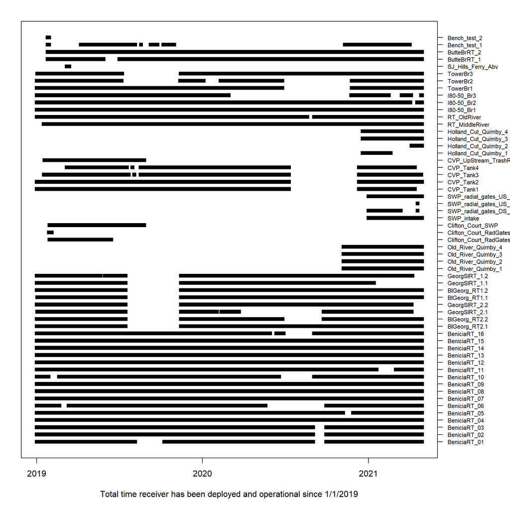

## Detection filters applied to real-time detections

Note: The detection filters used for filtering out false detections described below are fairly strict. The reasoning is that for the purposes of estimating survival, incorrectly keeping false detections can bias survival high, while incorrectly dropping real detections can bias detection probability low. In the latter case, under most circumstances, the survival estimate will remain mostly unchanged, although error will likely be higher. We have refined the detection filters to minimize the number of false detections that are included, as well as minimize the number of real detections that get dropped, but in situations of high uncertainty, we have taken the stricter approach and designed the filter to drop those detections for the reason stated above.

Filtering protocol:

1. “Multipath detection removal”: All detections that occur within 0.3 sec after an initial tag detection on the same receiver, that share the same Tag Code, will be removed from the data. These detections are “multipath detections” and are created by echos from the original tag transmission.
2. “3 detections within 6 minutes rule”: As a first cut to remove obviously false detections, only detections of “potentially valid fish detections” are kept in the database. Potentially valid fish detections are when at least 3 consecutive detections of a tag code occur at a general location site with no more than 3 minute gaps in between the three detections. These potentially valid detections are kept in the general database, but stricter criteria need to be met for them to be associated with a released fish (see below).
3. “Is there a fish at large with that TagCode?”: For detections of a TagCode to be assigned to an actual released fish with that same TagCode, the detections need to fall between the release time of that fish, and the release time + 150% of the estimated tag life for that fish’s tag. For example, if a fish is released on 1/1/2019, and it has a 60 day battery life, detections of that fish’s TagCode must fall between 1/1/2019 and 4/1/2019 to be associated to that fish.
4. “Detection density filter”: Once potentially valid fish detections have been determined and assigned to a specific fish, any 3 consecutive tag detections at an individual receiver must occur in a time window shorter than (Pulse Rate Interval (PRI) x 1.3 x 12)+ 1 seconds. For example, for a 10 sec PRI, if a detection does not have at least 2 other detections within 157 seconds of it, it is removed. The total consecutive detections that fulfill this condition are considered a potentially valid fish visit.
5. “PRI filter”: the PRI from the previous detection and the PRI to the next detection on an individual receiver is estimated for each detection of a potentially valid fish visit. At least one of the PRIs must be within 20% of the tag’s programmed PRI AND the standard deviation of the two PRIs must be smaller than 0.025. If these two conditions are not both met, the detection is dropped. If the detection is the first of a receiver visit, then the PRIs to the subsequent two detections are used. If the detection is the last of a receiver visit, the PRIs from the previous two detections are used.
6. “Detection density filter”: Bullet 4 above is rerun now that some detections have been dropped due to PRI filter.
7. “4-hit filter”: Once all the previous filters have been applied, if there are less than 4 detections total for a potentially valid fish visit, those visits are dropped. All remaining fish detections are kept and considered valid.

Additionally, a shed tag algorithm is used to remove detections for any tag that is detected continuously at one general location site for more than 30 days, and that was detected at that site a minimum of 20,000 times. The first 100 and last 100 detections of the general location site are kept for survival analyses, but the remaining detections are dropped.

## All-time Detection Efficiency from Beacon Tags (when operational)

```r
last_download <- aggregate(list(last_download = downloads$end), by = list(location = downloads$location), FUN = max, na.rm =T)

gen_loc_stats <- merge(unique(gen_locs[,c("location", "rkm")]), last_download, by = "location", all.x = T)

gen_loc_stats <- gen_loc_stats[order(gen_loc_stats$rkm, decreasing = T),]

gen_loc_stats <- merge(gen_loc_stats, aggregate(list(recv_start = gen_locs$start), by = list(location = gen_locs$location), min, na.rm = T), by = "location")

gen_loc_stats <- merge(gen_loc_stats, efficiency, by = "location", all.x= T)

gen_loc_stats$Active <- "No"
gen_loc_stats[which(as.numeric(difftime(Sys.time(), gen_loc_stats$last_download, units = "days")) < 7), "Active"] <- "Yes"

gen_loc_stats <- gen_loc_stats[order(gen_loc_stats$Active, gen_loc_stats$rkm, decreasing = T),]


kable(gen_loc_stats[,c("location",  "recv_start", "last_week_efficiency", "all_time_efficiency", "last_download", "Active")], align = "c", row.names = F,  "html") %>%
    kable_styling(bootstrap_options = c("striped", "hover", "condensed", "responsive", "bordered"), full_width = F, position = "left")%>%
    scroll_box(height = "400px")
```

| location | recv_start | last_week_efficiency | all_time_efficiency | last_download | Active |
| --- | --- | --- | --- | --- | --- |
| ButteBrRT_1 | 2019-01-25 13:00:00 | 98.3 | 81.6 | 2021-04-29 04:11:49 | Yes |
| ButteBrRT_2 | 2019-01-25 12:00:00 | 82.3 | 80.1 | 2021-04-29 03:24:36 | Yes |
| TowerBr1 | 2018-01-31 16:08:00 | 99.0 | 90.7 | 2021-04-29 04:52:21 | Yes |
| TowerBr2 | 2018-01-31 15:40:00 | 100.0 | 88.3 | 2021-04-29 04:52:43 | Yes |
| TowerBr3 | 2018-05-09 12:52:00 | 98.8 | 85.7 | 2021-04-29 03:00:26 | Yes |
| I80-50_Br1 | 2018-05-08 17:23:00 | 94.9 | 87.6 | 2021-04-29 05:00:26 | Yes |
| I80-50_Br2 | 2018-02-01 13:26:00 | 100.0 | 90.8 | 2021-04-29 04:49:49 | Yes |
| I80-50_Br3 | 2018-02-01 13:10:00 | 89.1 | 88.7 | 2021-04-29 04:55:37 | Yes |
| RT_OldRiver | 2018-03-15 14:54:00 | 94.5 | 86.7 | 2021-04-29 05:00:26 | Yes |
| RT_MiddleRiver | 2018-04-17 16:32:00 | 96.5 | 85.7 | 2021-04-29 05:00:26 | Yes |
| Holland_Cut_Quimby_2 | 2020-12-18 12:25:00 | 91.6 | 86.3 | 2021-04-29 04:00:26 | Yes |
| Holland_Cut_Quimby_3 | 2020-12-18 11:00:00 | 90.5 | 83.5 | 2021-04-29 05:00:26 | Yes |
| Holland_Cut_Quimby_4 | 2020-12-18 10:55:00 | 83.8 | 82.7 | 2021-04-29 05:00:36 | Yes |
| CVP_Tank2 | 2019-01-01 00:00:00 | 100.0 | 25.9 | 2021-04-29 04:44:12 | Yes |
| CVP_Tank3 | 2019-01-01 00:00:00 | 89.5 | 32.1 | 2021-04-27 09:54:15 | Yes |
| SWP_intake | 2021-01-01 00:00:00 | 100.0 | 95.3 | 2021-04-29 05:33:42 | Yes |
| SWP_radial_gates_US_2 | 2021-01-01 00:00:00 | 98.8 | 97.7 | 2021-04-29 04:57:22 | Yes |
| Old_River_Quimby_1 | 2020-11-06 11:35:00 | 88.0 | 83.9 | 2021-04-29 03:12:54 | Yes |
| Old_River_Quimby_2 | 2020-11-06 11:30:00 | 91.4 | 85.4 | 2021-04-29 03:11:38 | Yes |
| Old_River_Quimby_3 | 2020-11-06 13:20:00 | 90.3 | 86.1 | 2021-04-29 03:10:36 | Yes |
| Old_River_Quimby_4 | 2020-11-06 13:05:00 | 81.4 | 83.9 | 2021-04-29 04:28:18 | Yes |
| BlGeorg_RT1.1 | 2018-04-16 17:10:00 | 45.7 | 57.5 | 2021-04-29 04:20:18 | Yes |
| BlGeorg_RT1.2 | 2018-03-22 13:30:00 | 87.0 | 82.2 | 2021-04-29 05:00:36 | Yes |
| BlGeorg_RT2.1 | 2018-05-10 12:02:00 | 12.3 | 35.5 | 2021-04-29 04:07:58 | Yes |
| BlGeorg_RT2.2 | 2018-05-10 13:59:00 | 100.0 | 84.7 | 2021-04-29 04:31:22 | Yes |
| BeniciaRT_09 | 2018-04-25 09:26:00 | 95.6 | 86.7 | 2021-04-29 05:00:26 | Yes |
| BeniciaRT_10 | 2018-04-25 10:52:00 | 98.7 | 85.3 | 2021-04-29 04:00:26 | Yes |
| BeniciaRT_11 | 2018-04-25 13:08:00 | 93.8 | 87.0 | 2021-04-29 05:00:26 | Yes |
| BeniciaRT_12 | 2018-04-25 15:34:00 | 97.9 | 87.7 | 2021-04-29 05:00:26 | Yes |
| BeniciaRT_13 | 2018-04-24 14:51:00 | 97.4 | 86.3 | 2021-04-29 05:00:26 | Yes |
| BeniciaRT_14 | 2018-04-22 12:52:00 | 96.0 | 88.3 | 2021-04-29 05:00:26 | Yes |
| BeniciaRT_15 | 2018-04-24 13:12:00 | 97.0 | 89.3 | 2021-04-29 05:00:26 | Yes |
| BeniciaRT_16 | 2018-04-23 18:26:00 | 97.0 | 88.6 | 2021-04-29 05:00:26 | Yes |
| BeniciaRT_01 | 2018-04-25 15:54:00 | 97.2 | 88.1 | 2021-04-29 05:00:26 | Yes |
| BeniciaRT_02 | 2018-04-24 16:08:00 | 97.6 | 89.0 | 2021-04-29 05:00:26 | Yes |
| BeniciaRT_03 | 2018-04-24 18:09:00 | 96.9 | 89.2 | 2021-04-29 05:00:26 | Yes |
| BeniciaRT_04 | 2018-05-02 10:10:00 | 99.2 | 88.8 | 2021-04-29 05:00:26 | Yes |
| BeniciaRT_05 | 2018-05-02 10:59:00 | 94.9 | 84.8 | 2021-04-29 05:00:36 | Yes |
| BeniciaRT_06 | 2018-05-02 12:10:00 | 99.1 | 87.7 | 2021-04-29 05:00:26 | Yes |
| BeniciaRT_07 | 2018-04-25 18:16:00 | 98.9 | 85.4 | 2021-04-29 05:00:26 | Yes |
| BeniciaRT_08 | 2018-05-02 12:59:00 | 96.5 | 86.9 | 2021-04-29 05:00:26 | Yes |
| SJ_Hills_Ferry | 2019-02-04 20:33:00 | NA | NA | 2019-02-18 16:00:00 | No |
| SJ_Hills_Ferry_Abv | 2019-03-07 22:12:00 | NA | 86.3 | 2019-03-14 05:15:00 | No |
| SJ_Hills_Ferry_Blw | 2019-02-26 22:47:00 | NA | NA | 2019-02-28 13:16:00 | No |
| Holland_Cut_Quimby_1 | 2020-12-18 12:30:00 | NA | 83.5 | 2021-02-19 10:00:45 | No |
| CVP_Tank1 | 2019-01-01 00:00:00 | NA | 84.6 | 2021-04-13 03:50:39 | No |
| CVP_Tank4 | 2019-01-01 00:00:00 | NA | 17.6 | 2021-04-13 02:43:47 | No |
| CVP_UpStream_TrashRack | 2019-01-17 23:21:00 | NA | 55.4 | 2019-08-26 13:15:00 | No |
| Clifton_Court_RadGates_NE | 2019-01-28 18:23:00 | NA | 73.3 | 2019-06-14 13:16:00 | No |
| Clifton_Court_RadGates_SE | 2019-01-26 16:44:00 | NA | 78.6 | 2019-02-03 03:20:00 | No |
| Clifton_Court_SWP | 2019-01-28 22:54:00 | NA | 72.6 | 2019-08-26 13:18:00 | No |
| SWP_radial_gates_DS_1 | 2021-01-01 00:00:00 | NA | NA | NA | No |
| SWP_radial_gates_DS_2 | 2021-01-01 00:00:00 | NA | 96.8 | 2021-04-19 13:27:03 | No |
| SWP_radial_gates_US_1 | 2021-01-01 00:00:00 | NA | 13.9 | 2021-04-19 13:57:05 | No |
| GeorgSlRT_1.1 | 2018-03-22 18:18:00 | NA | 84.4 | 2021-01-13 18:14:37 | No |
| GeorgSlRT_1.2 | 2018-04-16 15:54:00 | NA | 69.0 | 2021-04-08 11:00:26 | No |
| GeorgSlRT_2.1 | 2018-03-29 10:14:00 | NA | 78.0 | 2021-04-07 00:00:36 | No |
| GeorgSlRT_2.2 | 2018-05-22 10:33:00 | NA | 83.1 | 2021-04-06 23:35:06 | No |
| DCCRT_1 | 2018-04-05 12:31:00 | NA | NA | NA | No |
| DCCRT_2 | 2018-05-17 11:06:00 | NA | NA | NA | No |
| Bench_test_1 | 2018-10-12 14:00:00 | NA | 76.3 | 2021-04-02 19:00:36 | No |
| Bench_test_2 | 2018-10-12 14:00:00 | NA | 78.1 | NA | No |

## Daily Detection Efficiency from Beacon Tags over last 30 days

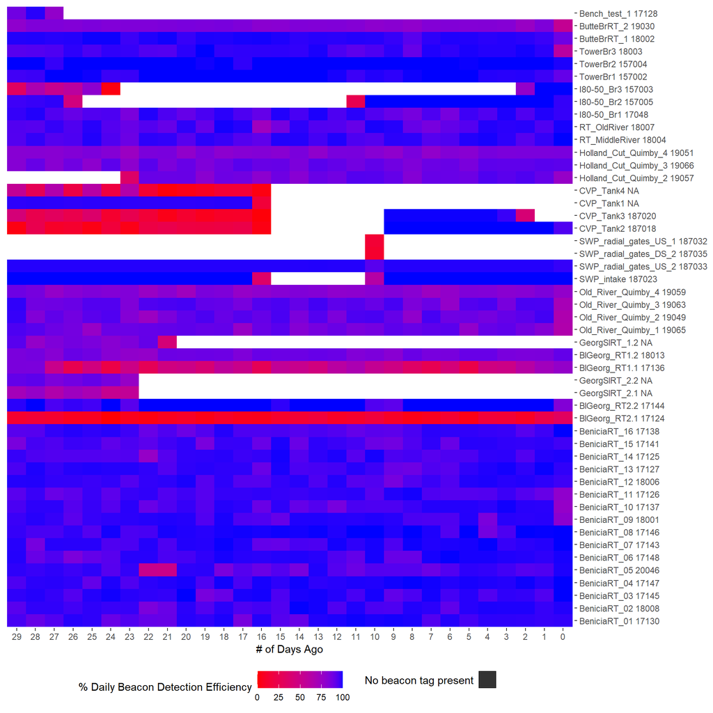

```r
library(ggplot2)


## plot just last months worth of daily efficiency
#last_month <- beacon_by_day[which(as.POSIXct(beacon_by_day$day, format = "%Y-%m-%d") > Sys.time()-60*60*24*30),]
last_month <- beacon_by_day[which(beacon_by_day$day > as.Date(Sys.time()-60*60*24*30)),]

## Ensure that recvs without any detections still show up. Find sites that should be ploted

sites <- gen_loc_stats[as.numeric(difftime(Sys.time(), gen_loc_stats$last_download, units = "days")) < 30,]
## Change order of data to plot decreasing rkm
sites <- sites[order(sites$rkm, decreasing = F),]

last_month$location <- factor(last_month$location, levels = unique(sites$location))
## Now plot a heatmap of percent fish distribution per region, per timestep

## make combined label for plot
current_locs <- gen_locs[is.na(gen_locs$stop),]
labels <- merge(data.frame(location = levels(last_month$location)), current_locs, all.x=T)
labels$recv_lab <- paste(labels$location, labels$recv, sep = " ")
## sort in same order as data
labels<- labels[order(match(labels$location,levels(last_month$location))),]

ggplot() +
  geom_tile(data=last_month, aes(x=factor(day), y=location, fill=day_efficiency, colour = "")) +
  scale_fill_gradient(low = "red", high = "blue", name = "% Daily Beacon Detection Efficiency", na.value = "black", limits=c(0, 100)) +
  scale_colour_manual(values = NA) +
  scale_x_discrete(labels = 29:0) +
  scale_y_discrete(position = "right", drop = F, labels = labels$recv_lab) +
  labs(x="# of Days Ago", y = NULL) +
  theme(legend.position="bottom", panel.background = element_blank()) +
  guides(colour = guide_legend(title = "No beacon tag present", override.aes = list(colour = "black")))
```

## Voltage for each ATS or Teknologics receiver

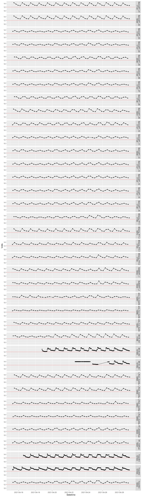